# Assignment 1 – AI/ML Applications in Civil Engineering

### Probabilistic Bearing Capacity Analysis using Monte Carlo Simulation and ANN

**Name:** Harshita Pulavarti  
**Course:** CE29208

## 1. Problem Description

A strip footing of width B = 2 m carries a centric vertical load and lies at the ground surface (Df = 0).  
The soil parameters are:

- Cohesion (c = 15) kPa
- Internal friction angle (φ = 30^\circ)
- Unit weight (γ = 20) kN/m³

The ultimate bearing capacity is calculated using **Terzaghi's bearing capacity equation**:

[ q_u = cN_c + \gamma D_f N_q + 0.5 B \gamma N_\gamma ]

Since (D_f = 0):

[ q_u = cN_c + 0.5 B \gamma N_\gamma ]

## Import Required Libraries

```python
import warnings
warnings.filterwarnings("ignore")
import numpy as np
import matplotlib.pyplot as plt
import seaborn as sns

from scipy.stats import lognorm
from sklearn.model_selection import train_test_split
from sklearn.neural_network import MLPRegressor
from sklearn.metrics import r2_score
from sklearn.preprocessing import StandardScaler
from sklearn.pipeline import Pipeline
```

## Deterministic Bearing Capacity Calculation

```python
# Compute bearing capacity factors using phi = 30 degrees

phi = np.radians(30)

Nq = np.exp(np.pi*np.tan(phi))*(np.tan(np.radians(45)+phi/2)**2)
Nc = (Nq - 1)/np.tan(phi)
Ngamma = 2*(Nq + 1)*np.tan(phi)

print("Nc =", Nc)
print("Nq =", Nq)
print("Ngamma =", Ngamma)
```

```
Nc = 30.13962779151908
Nq = 18.40112221870866
Ngamma = 22.402486271104543
```

```python
# Given soil parameters
c = 15
gamma = 20
B = 2

# Terzaghi equation
qu_det = c*Nc + 0.5*B*gamma*Ngamma

print("Deterministic Bearing Capacity =", qu_det)
```

```
Deterministic Bearing Capacity = 900.144142294877
```

## Statistical Model Specification

The soil parameters (c, φ, γ) are assumed to follow lognormal distributions.  
The coefficient of variation (CoV) for each parameter is assumed to be 0.10.

```python
# Lognormal Parameter Conversion

# Mean values of soil parameters
mean_c = 15
mean_gamma = 20

# Friction angle converted to tan(phi)
mean_tanphi = np.tan(np.radians(30))

# Coefficient of variation (given in assignment)
cov = 0.10


# Function to convert mean and CoV into lognormal parameters (mu, sigma)
def lognormal_params(mean, cov):

    # Standard deviation in log-space
    sigma = np.sqrt(np.log(1 + cov**2))

    # Mean in log-space
    mu = np.log(mean) - sigma**2 / 2

    return mu, sigma


# Compute lognormal parameters for each soil property
mu_c, sigma_c = lognormal_params(mean_c, cov)
mu_gamma, sigma_gamma = lognormal_params(mean_gamma, cov)
mu_tanphi, sigma_tanphi = lognormal_params(mean_tanphi, cov)
```

## Distribution of Input Variables

Random samples of the soil parameters are generated from the assumed lognormal distributions to visualize their variability.

```python
#Generate Samples for Input Distributions

# Number of samples for visualizing input distributions
N = 10000

# Generate lognormal random samples for soil parameters
c_samples = np.random.lognormal(mu_c, sigma_c, N)
gamma_samples = np.random.lognormal(mu_gamma, sigma_gamma, N)
tanphi_samples = np.random.lognormal(mu_tanphi, sigma_tanphi, N)
```

## Monte Carlo Simulation

Monte Carlo simulation is performed with 500 realizations of the soil parameters to estimate the probabilistic distribution of ultimate bearing capacity.

```python
# Number of Monte Carlo simulations
N = 500

# Randomly generate soil parameters from their lognormal distributions
c = np.random.lognormal(mu_c, sigma_c, N)
gamma = np.random.lognormal(mu_gamma, sigma_gamma, N)
tanphi = np.random.lognormal(mu_tanphi, sigma_tanphi, N)

# Convert tan(phi) back to friction angle phi
phi = np.arctan(tanphi)

# Footing width
B = 2

# Empty list to store computed bearing capacities
qu = []

# Loop through all samples to compute ultimate bearing capacity
for i in range(N):

    # Calculate bearing capacity factors for each phi
    Nq = np.exp(np.pi*np.tan(phi[i]))*(np.tan(np.radians(45)+phi[i]/2)**2)
    Nc = (Nq - 1)/np.tan(phi[i])
    Ngamma = 2*(Nq + 1)*np.tan(phi[i])

    # Terzaghi bearing capacity formula
    qu_i = c[i]*Nc + 0.5*B*gamma[i]*Ngamma

    # Store result
    qu.append(qu_i)

# Convert list to NumPy array
qu = np.array(qu)
```

## Distribution of Bearing Capacity

The distribution of ultimate bearing capacity obtained from Monte Carlo simulation is shown below along with the fitted lognormal distribution.

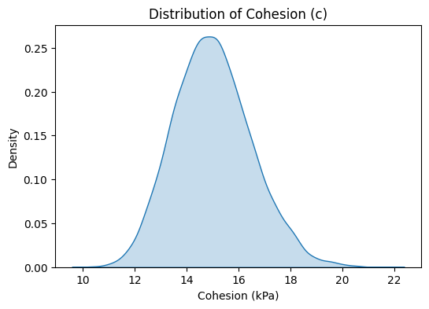

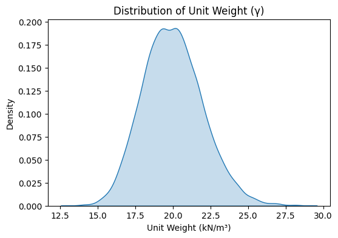

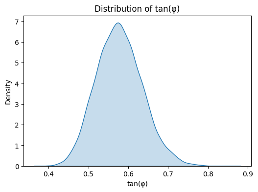

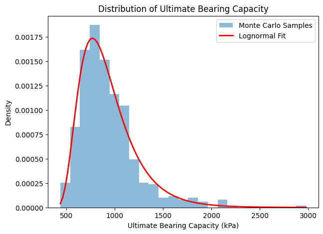

```python
import seaborn as sns
import matplotlib.pyplot as plt
import numpy as np
from scipy.stats import lognorm

# Cohesion distribution
plt.figure(figsize=(6,4))
sns.kdeplot(c_samples, fill=True)
plt.title("Distribution of Cohesion (c)")
plt.xlabel("Cohesion (kPa)")
plt.ylabel("Density")
plt.show()

# Unit weight distribution
plt.figure(figsize=(6,4))
sns.kdeplot(gamma_samples, fill=True)
plt.title("Distribution of Unit Weight (γ)")
plt.xlabel("Unit Weight (kN/m³)")
plt.ylabel("Density")
plt.show()

# tan(phi) distribution
plt.figure(figsize=(6,4))
sns.kdeplot(tanphi_samples, fill=True)
plt.title("Distribution of tan(φ)")
plt.xlabel("tan(φ)")
plt.ylabel("Density")
plt.show()


# -----------------------------
# Distribution of Bearing Capacity (Monte Carlo Output)
# -----------------------------

shape, loc, scale = lognorm.fit(qu)

x = np.linspace(min(qu), max(qu), 100)
pdf = lognorm.pdf(x, shape, loc, scale)

plt.figure(figsize=(7,5))

plt.hist(qu, bins=25, density=True, alpha=0.5, label="Monte Carlo Samples")
plt.plot(x, pdf, 'r', linewidth=2, label="Lognormal Fit")

plt.xlabel("Ultimate Bearing Capacity (kPa)")
plt.ylabel("Density")
plt.title("Distribution of Ultimate Bearing Capacity")

plt.legend()
plt.show()
```

## Statistical Results

The following table summarizes the statistical properties of the ultimate bearing capacity obtained from the Monte Carlo simulation.

```python
mean_qu = np.mean(qu)
std_qu = np.std(qu)
cov_qu = std_qu/mean_qu
p5 = np.percentile(qu,5)
p95 = np.percentile(qu,95)

mean_qu, std_qu, cov_qu, p5, p95
```

```
(np.float64(932.7693191752902),
 np.float64(305.59492824797826),
 np.float64(0.3276211191403364),
 np.float64(579.4080042582069),
 np.float64(1511.25509598907))
```

```python
# Statistical Results(proper table)
import pandas as pd

results = pd.DataFrame({
    "Statistic": [
        "Mean qu (kPa)",
        "Std deviation (kPa)",
        "Coefficient of Variation",
        "5th percentile (kPa)",
        "95th percentile (kPa)"
    ],
    "Value": [
        round(mean_qu,2),
        round(std_qu,2),
        round(cov_qu,3),
        round(p5,2),
        round(p95,2)
    ]
})

results
```

|  | Statistic | Value |
| --- | --- | --- |
| 0 | Mean qu (kPa) | 932.770 |
| 1 | Std deviation (kPa) | 305.590 |
| 2 | Coefficient of Variation | 0.328 |
| 3 | 5th percentile (kPa) | 579.410 |
| 4 | 95th percentile (kPa) | 1511.260 |

## ANN Surrogate Model

An Artificial Neural Network (ANN) is trained to predict the ultimate bearing capacity using soil parameters as inputs.

```python
X = np.column_stack((c,phi,gamma))
y = qu

X_train,X_temp,y_train,y_temp = train_test_split(X,y,test_size=0.3)

X_val,X_test,y_val,y_test = train_test_split(X_temp,y_temp,test_size=0.5)

# Train Neural Network

model = Pipeline([
    ('scaler', StandardScaler()),
    ('mlp', MLPRegressor(hidden_layer_sizes=(12,12),
                         activation='relu',
                         max_iter=5000,
                         random_state=1))
])

model.fit(X_train,y_train)
```

```
Pipeline(steps=[('scaler', StandardScaler()),
                ('mlp',
                 MLPRegressor(hidden_layer_sizes=(12, 12), max_iter=5000,
                              random_state=1))])
```

## Model Performance

The ANN model performance is evaluated using the coefficient of determination (R²).

```python
# Model Performance

pred = model.predict(X_test)

r2 = r2_score(y_test,pred)

print(f"R² Score of ANN Model: {r2:.4f}")
```

```
R² Score of ANN Model: 0.9975
```

## Loss vs Epoch (Training)

This will produce a graph showing how the ANN training error decreases over epochs.

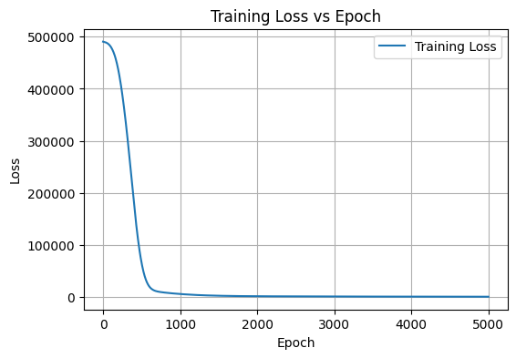

```python
loss_curve = model.named_steps['mlp'].loss_curve_

plt.figure(figsize=(6,4))
plt.plot(loss_curve, label="Training Loss")

plt.xlabel("Epoch")
plt.ylabel("Loss")
plt.title("Training Loss vs Epoch")

plt.legend()
plt.grid(True)
plt.show()
```

## Predicted vs Actual Plot

The predicted values from the ANN model are compared with the actual Monte Carlo results.

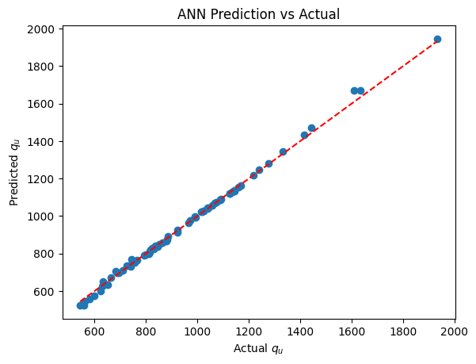

```python
plt.scatter(y_test,pred)

plt.plot([min(y_test),max(y_test)],
         [min(y_test),max(y_test)],
         'r--')

plt.xlabel("Actual $q_u$")
plt.ylabel("Predicted $q_u$")

plt.title("ANN Prediction vs Actual")

plt.show()
```

## Sensitivity/Importance Analysis

Cohesion (c) has a moderate influence because it contributes linearly to the bearing capacity through the term cNc in Terzaghi’s equation.

The unit weight (γ) has the least influence among the three parameters because it appears only in the third term of the equation and its effect on the final bearing capacity is relatively smaller.

This indicates that uncertainty in the friction angle contributes the most to the variability of the ultimate bearing capacity.

## Reporting and Conclusions

Summary of Findings

The deterministic bearing capacity calculated using the mean soil parameters was approximately 900 kPa.

These results indicate that the ultimate bearing capacity varies significantly due to uncertainty in soil parameters.

The ANN surrogate model was trained to predict the ultimate bearing capacity using soil parameters as inputs. The model achieved an R² value of approximately 0.997, indicating that the ANN accurately approximates the relationship between soil parameters and bearing capacity.

Suggestions to Reduce Uncertainty

To reduce uncertainty in foundation design, more accurate characterization of the friction angle should be performed. This can be achieved by conducting additional laboratory tests such as direct shear tests or triaxial tests. Improving the accuracy of friction angle measurements will significantly reduce uncertainty in predicting the ultimate bearing capacity and lead to safer and more reliable foundation designs.